# DATA606 Final Project

### Liberal Arts vs Physical Sciences

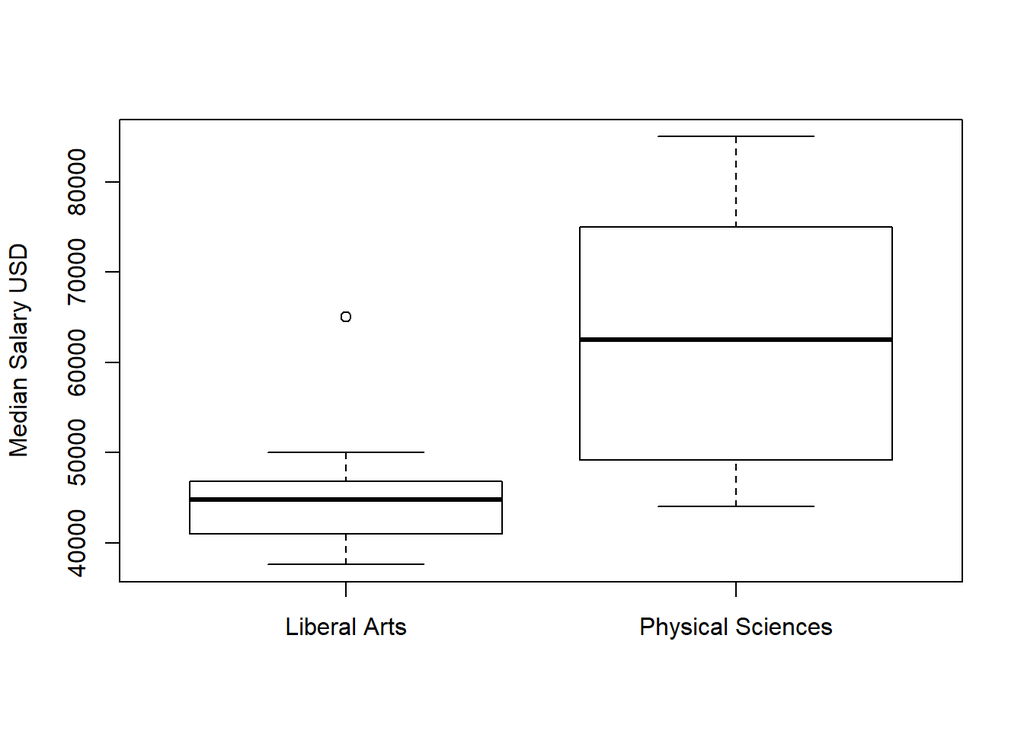

```r
boxplot(allAgesLibArts$Median, allAgesScinces$Median, names = c("Liberal Arts", "Physical Sciences"), ylab = "Median Salary USD")
```

```r
t.test(allAgesLibArts$Median, allAgesScinces$Median, alternative = "less")
```

```
##
##  Welch Two Sample t-test
##
## data:  allAgesLibArts$Median and allAgesScinces$Median
## t = -3.0526, df = 9.093, p-value = 0.006787
## alternative hypothesis: true difference in means is less than 0
## 95 percent confidence interval:
##      -Inf -6946.71
## sample estimates:
## mean of x mean of y
##  45441.67  62800.00
```

```r
ks.test(allAgesLibArts$Median, allAgesScinces$Median, alternative = "greater")
```

```
##
##  Two-sample Kolmogorov-Smirnov test
##
## data:  allAgesLibArts$Median and allAgesScinces$Median
## D^+ = 0.70833, p-value = 0.008094
## alternative hypothesis: the CDF of x lies above that of y
```

### Tests summary

From the tesets results, Engineering is the major that fetches the highest median salry. This is followed by Physical Science (which has the same median salary as Industrial and Organizational Psycology), Liberal Arts, Psycology & Social Work.

## Linear Regression Model

##### For the linear regression model, I will consider the Unemployment rate and the median salary for the data sets to see if there is any correlation between unemployment rate and median salary because I have the belief that the pressure of unemployment rate can have an impact on salary because people will tend to accept what they can be offered due to low demand in their skill-set. But I want to substantiate this with data. If the residuals of the model do not show the necessary behavior of Normal Distribution and Constant Variance, we will perform a Box-Cox transformation on the data to get an exponential factor to improve the model.

### First fit

```r
allAgeUnEmp_fit <-lm(allStudents$Median ~ allStudents$Unemployment_rate)
```

```r
summary(allAgeUnEmp_fit)
```

```
##
## Call:
## lm(formula = allStudents$Median ~ allStudents$Unemployment_rate)
##
## Residuals:
##    Min     1Q Median     3Q    Max
## -23370  -8995  -3272   8079  64676
##
## Coefficients:
##                               Estimate Std. Error t value Pr(>|t|)
## (Intercept)                      70097       3380  20.738  < 2e-16 ***
## allStudents$Unemployment_rate  -231551      55906  -4.142 5.41e-05 ***
## ---
## Signif. codes:  0 '***' 0.001 '**' 0.01 '*' 0.05 '.' 0.1 ' ' 1
##
## Residual standard error: 14060 on 171 degrees of freedom
## Multiple R-squared:  0.09117,    Adjusted R-squared:  0.08586
## F-statistic: 17.15 on 1 and 171 DF,  p-value: 5.406e-05
```

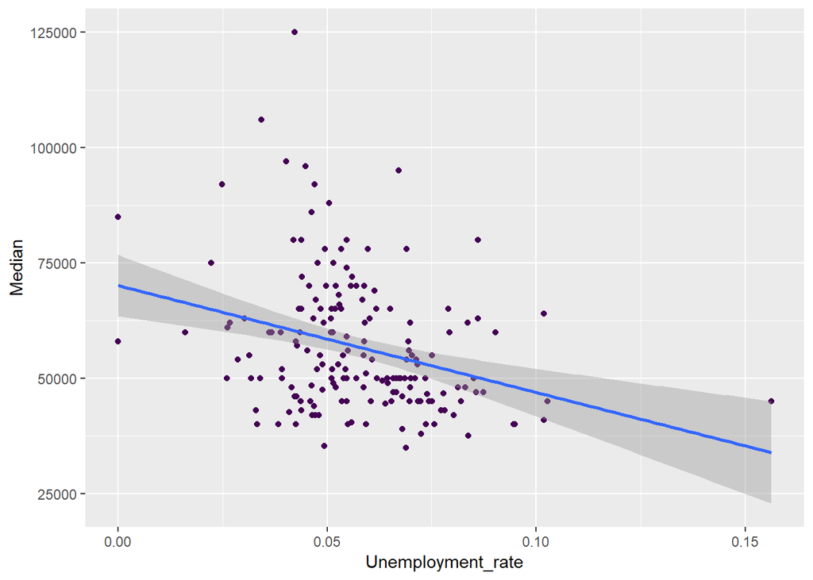

```r
ggplot(allStudents, aes(x = Unemployment_rate, y = Median)) + geom_point(color = "#440154") + geom_smooth(method = "lm", formula = y~x)
```

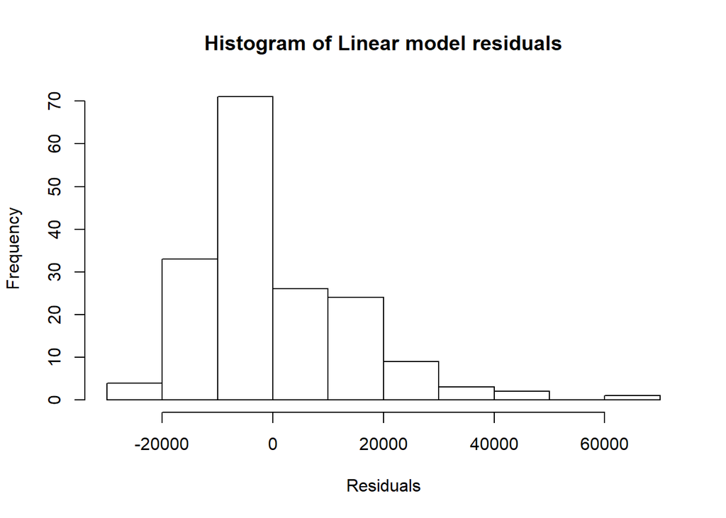

```r
hist(allAgeUnEmp_fit$residuals, xlab = "Residuals", main = "Histogram of Linear model residuals")
```

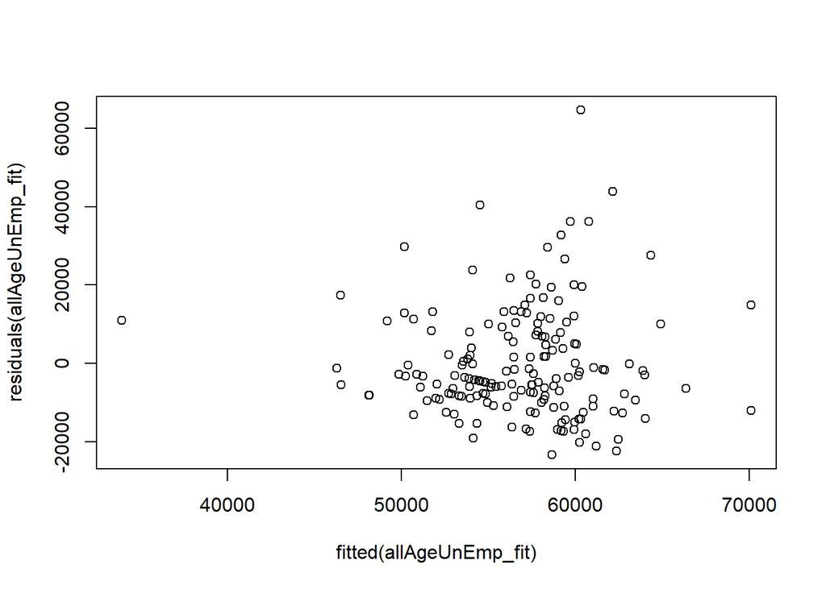

```r
plot(fitted(allAgeUnEmp_fit), residuals(allAgeUnEmp_fit))
```

##### It appears the residuals do not show characteristics of Normal Distribution and Constant Variance. Let’s try to improve the linear model through an exponential factor that will be gotten by performing a Box-Cox transformation on the linear model.

```r
boxcox_ExpM <- boxcox(allAgeUnEmp_fit)
```

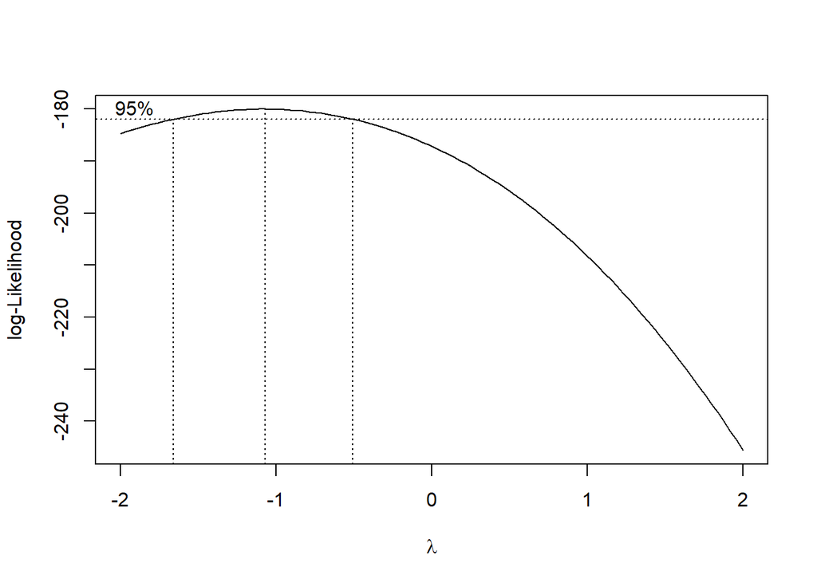

```r
optimised_M <- boxcox_ExpM %>% as.data.frame() %>% .[which.max(.$y),1]
```

```r
optimised_M
```

```
## [1] -1.070707
```

### Re-fitting the model

```r
allAgeUnEmp_refit <- lm(allStudents$Median^optimised_M ~ allStudents$Unemployment_rate)
```

```r
summary(allAgeUnEmp_refit)
```

```
##
## Call:
## lm(formula = allStudents$Median^optimised_M ~ allStudents$Unemployment_rate)
##
## Residuals:
##        Min         1Q     Median         3Q        Max
## -4.646e-06 -1.475e-06  2.614e-07  1.295e-06  5.141e-06
##
## Coefficients:
##                                Estimate Std. Error t value Pr(>|t|)
## (Intercept)                   6.755e-06  4.666e-07  14.476  < 2e-16 ***
## allStudents$Unemployment_rate 3.272e-05  7.718e-06   4.239 3.66e-05 ***
## ---
## Signif. codes:  0 '***' 0.001 '**' 0.01 '*' 0.05 '.' 0.1 ' ' 1
##
## Residual standard error: 1.941e-06 on 171 degrees of freedom
## Multiple R-squared:  0.09509,    Adjusted R-squared:  0.0898
## F-statistic: 17.97 on 1 and 171 DF,  p-value: 3.664e-05
```

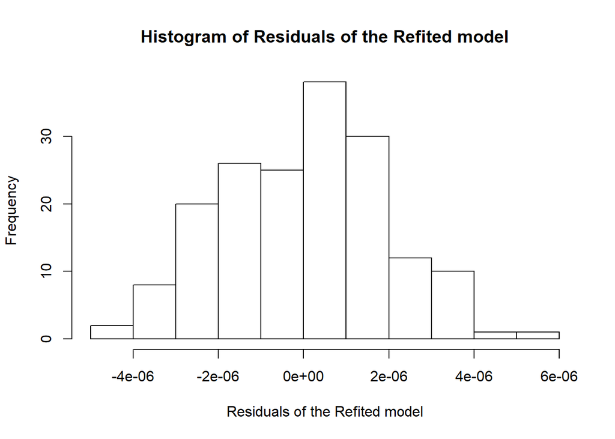

```r
hist(allAgeUnEmp_refit$residuals, xlab = "Residuals of the Refited model", main = "Histogram of Residuals of the Refited model")
```

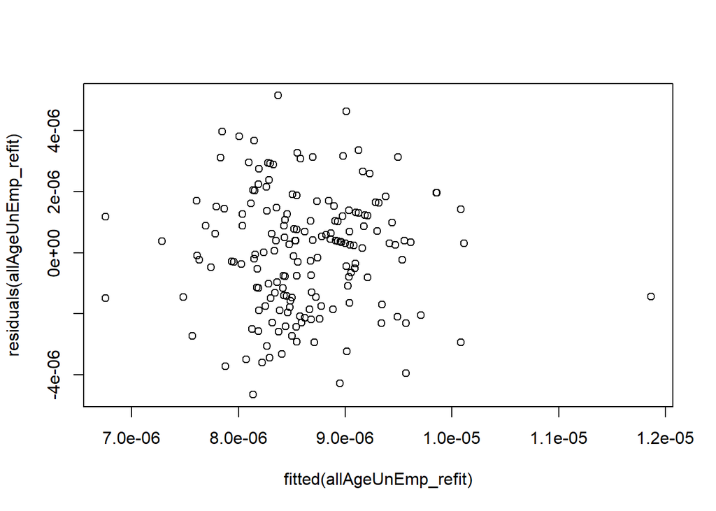

```r
plot(fitted(allAgeUnEmp_refit), residuals(allAgeUnEmp_refit))
```

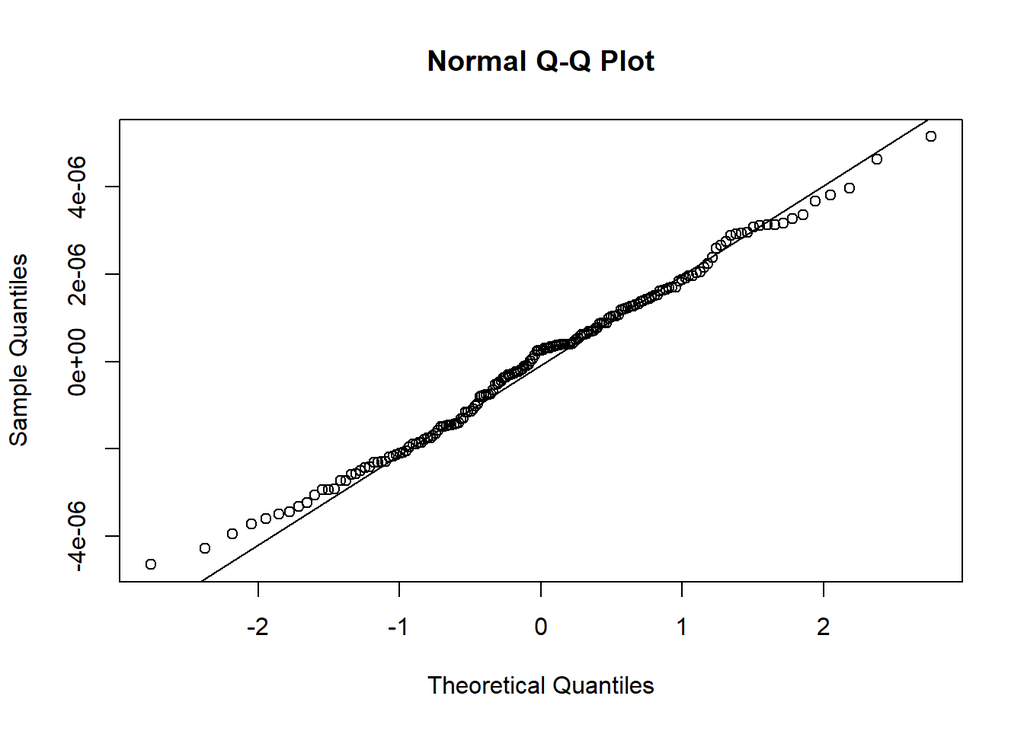

```r
qqnorm(residuals(allAgeUnEmp_refit))
qqline(residuals(allAgeUnEmp_refit))
```

```r
allStudents_A <- allStudents %>% mutate(newMedian  = Median^optimised_M)
```

```r
datatable(allStudents_A, class = 'cell-border stripe', options = list(
  initComplete = JS(
    "function(settings, json) {",
    "$(this.api().table().header()).css({'background-color': '#440154', 'color': '#fff', 'text-align': 'center !important'});",
    "$(this.api().table().body()).css({'color': '#000', 'text-align': 'center !important'});",
    "}")
))
```

|  | Major_code | Major | Major_category | Total | Employed | Employed_full_time_year_round | Unemployed | Unemployment_rate | Median | P25th | P75th | newMedian |
| --- | --- | --- | --- | --- | --- | --- | --- | --- | --- | --- | --- | --- |
| 1 | 1100 | GENERAL AGRICULTURE | Agriculture &amp; Natural Resources | 128148 | 90245 | 74078 | 2423 | 0.026147106 | 50000 | 34000 | 80000 | 9.30635449035368e-06 |
| 2 | 1101 | AGRICULTURE PRODUCTION AND MANAGEMENT | Agriculture &amp; Natural Resources | 95326 | 76865 | 64240 | 2266 | 0.028636059 | 54000 | 36000 | 80000 | 8.57023123749052e-06 |
| 3 | 1102 | AGRICULTURAL ECONOMICS | Agriculture &amp; Natural Resources | 33955 | 26321 | 22810 | 821 | 0.030248324 | 63000 | 40000 | 98000 | 7.26628016641661e-06 |
| 4 | 1103 | ANIMAL SCIENCES | Agriculture &amp; Natural Resources | 103549 | 81177 | 64937 | 3619 | 0.0426789 | 46000 | 30000 | 72000 | 1.0175417105127e-05 |
| 5 | 1104 | FOOD SCIENCE | Agriculture &amp; Natural Resources | 24280 | 17281 | 12722 | 894 | 0.049188446 | 62000 | 38500 | 90000 | 7.39183616463001e-06 |
| 6 | 1105 | PLANT SCIENCE AND AGRONOMY | Agriculture &amp; Natural Resources | 79409 | 63043 | 51077 | 2070 | 0.031790887 | 50000 | 35000 | 75000 | 9.30635449035368e-06 |
| 7 | 1106 | SOIL SCIENCE | Agriculture &amp; Natural Resources | 6586 | 4926 | 4042 | 264 | 0.050867052 | 63000 | 39400 | 88000 | 7.26628016641661e-06 |
| 8 | 1199 | MISCELLANEOUS AGRICULTURE | Agriculture &amp; Natural Resources | 8549 | 6392 | 5074 | 261 | 0.039230422 | 52000 | 35000 | 75000 | 8.92363656769931e-06 |
| 9 | 1302 | FORESTRY | Agriculture &amp; Natural Resources | 69447 | 48228 | 39613 | 2144 | 0.042563329 | 58000 | 40500 | 80000 | 7.93896644752185e-06 |
| 10 | 1303 | NATURAL RESOURCES MANAGEMENT | Agriculture &amp; Natural Resources | 83188 | 65937 | 50595 | 3789 | 0.054341279 | 52000 | 37100 | 75000 | 8.92363656769931e-06 |

[output cut: 163 more lines]

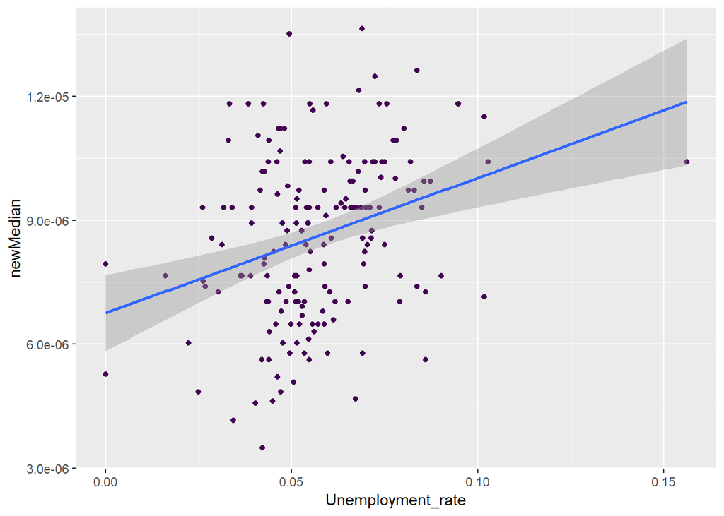

```r
ggplot(allStudents_A, aes(x = Unemployment_rate, y = newMedian)) +
  geom_point(color = '#440154')+
  geom_smooth(method = "lm", formula = y~x)
```

### Dealing with Outliers

```r
allStudents_O <- allStudents_A %>% filter(Unemployment_rate > 0 & Unemployment_rate != max(Unemployment_rate))
```

```r
allStudents_o_refit <- lm(allStudents_O$newMedian ~ allStudents_O$Unemployment_rate)
```

```r
summary(allStudents_o_refit)
```

```
##
## Call:
## lm(formula = allStudents_O$newMedian ~ allStudents_O$Unemployment_rate)
##
## Residuals:
##        Min         1Q     Median         3Q        Max
## -4.616e-06 -1.475e-06  1.990e-07  1.290e-06  5.153e-06
##
## Coefficients:
##                                  Estimate Std. Error t value Pr(>|t|)
## (Intercept)                     6.611e-06  5.382e-07  12.285  < 2e-16 ***
## allStudents_O$Unemployment_rate 3.539e-05  8.999e-06   3.933 0.000122 ***
## ---
## Signif. codes:  0 '***' 0.001 '**' 0.01 '*' 0.05 '.' 0.1 ' ' 1
##
## Residual standard error: 1.949e-06 on 168 degrees of freedom
## Multiple R-squared:  0.08432,    Adjusted R-squared:  0.07887
## F-statistic: 15.47 on 1 and 168 DF,  p-value: 0.0001225
```

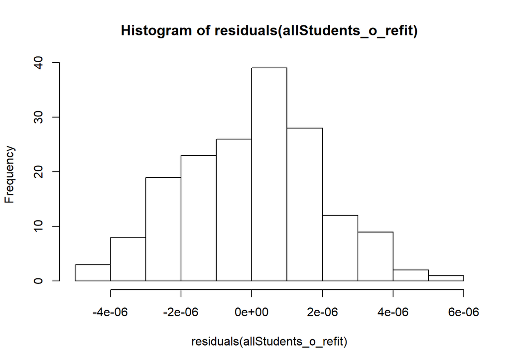

```r
hist(residuals(allStudents_o_refit))
```

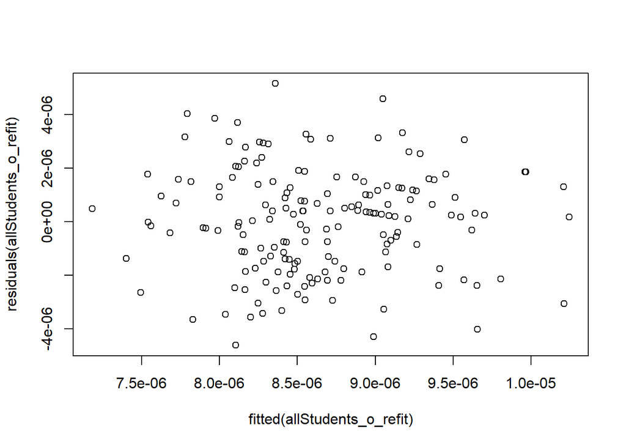

```r
plot(fitted(allStudents_o_refit), residuals(allStudents_o_refit))
```

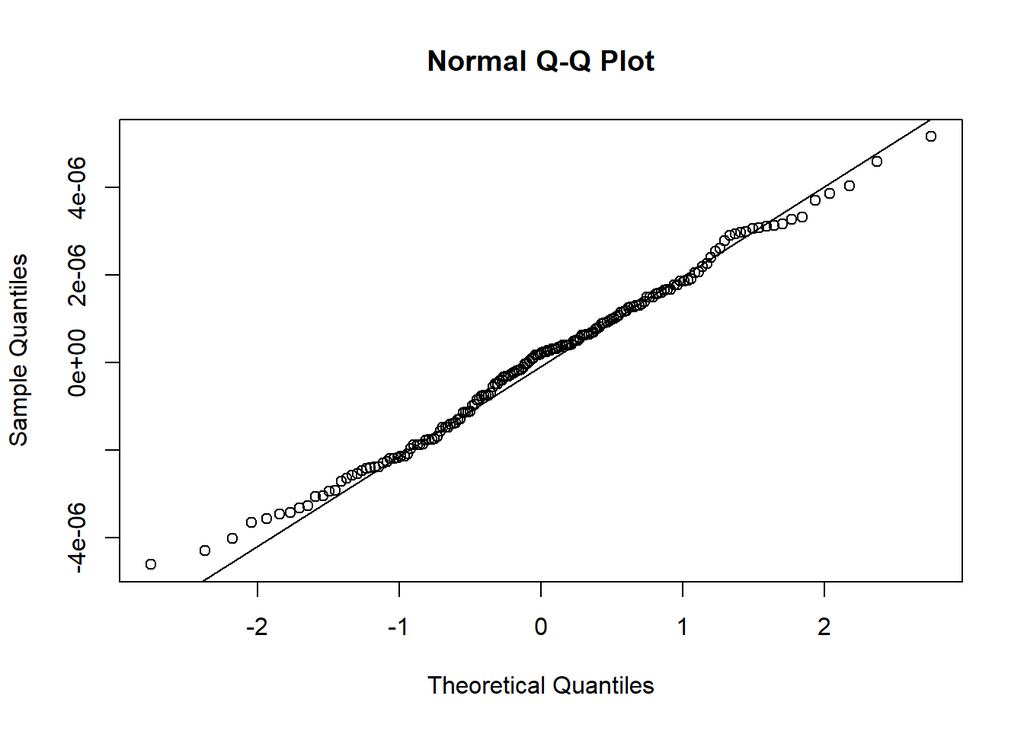

```r
qqnorm(resid(allStudents_o_refit))
qqline(resid(allStudents_o_refit))
```

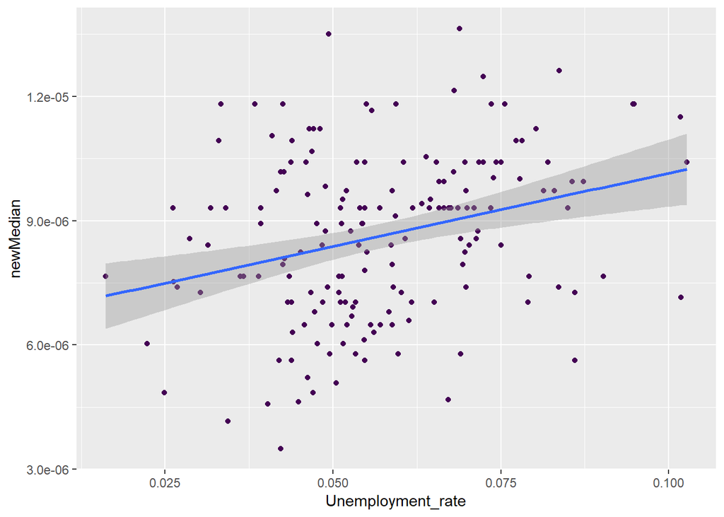

```r
ggplot(allStudents_O, aes(x = Unemployment_rate, y = newMedian)) +
  geom_point(color = '#440154')+
  geom_smooth(method = "lm", formula = y~x)
```

### Meadian salary & Unemployment Rate

```r
allStudentsUnEmp <- allStudents %>% dplyr::select(Major, Unemployment_rate) %>% arrange(Unemployment_rate)
```

```r
datatable(allStudentsUnEmp, class = 'cell-border stripe', options = list(
  initComplete = JS(
    "function(settings, json) {",
    "$(this.api().table().header()).css({'background-color': '#440154', 'color': '#fff', 'text-align': 'center !important'});",
    "$(this.api().table().body()).css({'color': '#000', 'text-align': 'center !important'});",
    "}")
))
```

|  | Major | Unemployment_rate |
| --- | --- | --- |
| 1 | EDUCATIONAL ADMINISTRATION AND SUPERVISION | 0 |
| 2 | GEOLOGICAL AND GEOPHYSICAL ENGINEERING | 0 |
| 3 | PHARMACOLOGY | 0.016110797 |
| 4 | MATERIALS SCIENCE | 0.022333333 |
| 5 | MATHEMATICS AND COMPUTER SCIENCE | 0.024900398 |
| 6 | GENERAL AGRICULTURE | 0.026147106 |
| 7 | TREATMENT THERAPY PROFESSIONS | 0.026291603 |
| 8 | NURSING | 0.026796818 |
| 9 | AGRICULTURE PRODUCTION AND MANAGEMENT | 0.028636059 |
| 10 | AGRICULTURAL ECONOMICS | 0.030248324 |

[output cut: 163 more lines]

```r
salaries <- allStudents  %>% dplyr::select(Major,Median) %>% arrange(Median)
```

```r
datatable(salaries, class = 'cell-border stripe', options = list(
  initComplete = JS(
    "function(settings, json) {",
    "$(this.api().table().header()).css({'background-color': '#440154', 'color': '#fff', 'text-align': 'center !important'});",
    "$(this.api().table().body()).css({'color': '#000', 'text-align': 'center !important'});",
    "}")
))
```

|  | Major | Median |
| --- | --- | --- |
| 1 | NEUROSCIENCE | 35000 |
| 2 | EARLY CHILDHOOD EDUCATION | 35300 |
| 3 | STUDIO ARTS | 37600 |
| 4 | HUMAN SERVICES AND COMMUNITY ORGANIZATION | 38000 |
| 5 | COUNSELING PSYCHOLOGY | 39000 |
| 6 | VISUAL AND PERFORMING ARTS | 40000 |
| 7 | ELEMENTARY EDUCATION | 40000 |
| 8 | TEACHER EDUCATION: MULTIPLE LEVELS | 40000 |
| 9 | LIBRARY SCIENCE | 40000 |
| 10 | COMPOSITION AND RHETORIC | 40000 |

[output cut: 163 more lines]

## References

[The Economic Guide To Picking A College Major](https://fivethirtyeight.com/features/the-economic-guide-to-picking-a-college-major/)

[As More Attend College, Majors Become More Career-Focused](https://fivethirtyeight.com/features/as-more-attend-college-majors-become-more-career-focused/)

[FiveThirtyEight Github Repo: college majors](https://github.com/fivethirtyeight/data/tree/master/college-majors)

[How to Interpret a Regression Model with Low R-squared and Low P values](https://blog.minitab.com/blog/adventures-in-statistics-2/how-to-interpret-a-regression-model-with-low-r-squared-and-low-p-values)